# 04_prophet slides

## Prophet Model Incorporated with Bayesian Analysis

The manager notes from previous surveys that many American customers who previously stayed at their hotel traveled to Portugal via London with British Airways.

You are tasked with building a [Prophet](https://facebook.github.io/prophet/) model that can forecast passenger numbers traveling from San Francisco to London with British Airways as accurately as possible.

Additionally, they would also like the Prophet model to account for uncertainty in the trend and seasonality components.

#### In this notebook

- **Milestone 1: Forecasting Air Passenger Numbers**
  - Fit the model
  - Plot the forecast components of the model
  - Calculate the RMSE
- **Milestone 2: AR(1) Time Series Analysis**
- **Milestone 3: Forecasting Volatility with Bayesian Time Series Methods**

```python
import pandas as pd
import numpy as np

from fbprophet import Prophet

import statsmodels.api as sm
from statsmodels.tsa.arima.model import ARIMA
from statsmodels.tsa.seasonal import seasonal_decompose
from statsmodels.graphics.tsaplots import plot_acf, plot_pacf

from sklearn.metrics import mean_squared_error

%matplotlib inline
import matplotlib.pyplot as plt
import seaborn as sns

np.random.seed(42)
idx = pd.IndexSlice
```

```python
import fbprophet
fbprophet.__version__
```

```
'0.7.1'
```

## Milestone 1: Forecasting Air Passenger Numbers

To the Top

You are tasked with building a Prophet model that can forecast passenger numbers traveling from San Francisco to London with British Airways as accurately as possible.

- [Quick Start - Python API](https://facebook.github.io/prophet/docs/quick_start.html#python-api)
- [Trend Changepoints](https://facebook.github.io/prophet/docs/trend_changepoints.html#automatic-changepoint-detection-in-prophet)

```python
!head -n3 data/british_airways.csv
```

```
Date,Adjusted Passenger Count
2005-07-01,21686
2005-08-01,20084
```

```
<class 'pandas.core.frame.DataFrame'>
RangeIndex: 129 entries, 0 to 128
Data columns (total 2 columns):
 #   Column  Non-Null Count  Dtype
---  ------  --------------  -----
 0   ds      129 non-null    datetime64[ns]
 1   y       129 non-null    int64
dtypes: datetime64[ns](1), int64(1)
memory usage: 2.1 KB
```

|  | ds | y |
| --- | --- | --- |
| 0 | 2005-07-01 | 21686 |
| 1 | 2005-08-01 | 20084 |

|  | ds | y |
| --- | --- | --- |
| 127 | 2016-02-01 | 16230 |
| 128 | 2016-03-01 | 18392 |

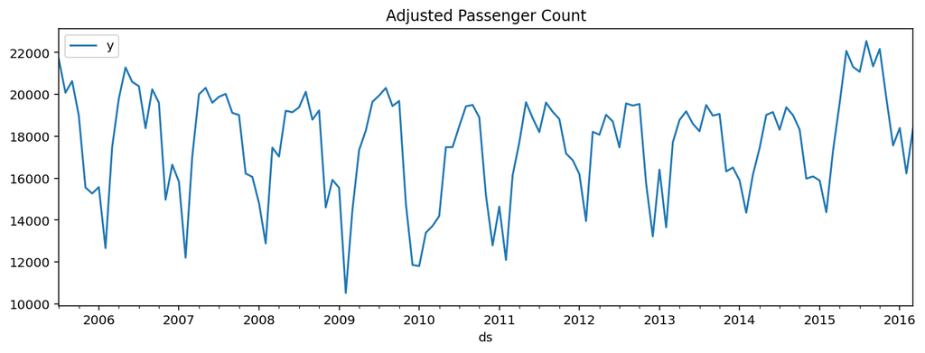

```python
df = (pd.read_csv('data/british_airways.csv', parse_dates=['Date'])
      .rename(columns={'Date': 'ds', 'Adjusted Passenger Count': 'y'}))

df.info()
df.head(2)
df.tail(2)

_ = df.plot(x='ds', y='y', figsize=(12, 4), title='Adjusted Passenger Count')
```

```python
train, test = df.iloc[:115], df.iloc[115:]

len(train), len(test)
```

```
(115, 14)
```

#### Fit the model

To the Top

```python
m = Prophet()
m.fit(train)
```

```
INFO:fbprophet:Disabling weekly seasonality. Run prophet with weekly_seasonality=True to override this.
INFO:fbprophet:Disabling daily seasonality. Run prophet with daily_seasonality=True to override this.
```

```
<fbprophet.forecaster.Prophet at 0x7fe132cc6ca0>
```

Predictions are then made on a dataframe with a column `ds` containing the dates for which a prediction is to be made.  
You can get a suitable dataframe that extends into the future a specified number of days using the helper method `Prophet.make_future_dataframe`.

```python
future = m.make_future_dataframe(periods=len(test), freq='M')
future.tail(2)
```

|  | ds |
| --- | --- |
| 127 | 2016-01-31 |
| 128 | 2016-02-29 |

```python
forecast = m.predict(future)
forecast.tail(2)
```

|  | ds | trend | yhat_lower | yhat_upper | trend_lower | trend_upper | additive_terms | additive_terms_lower | additive_terms_upper | yearly | yearly_lower | yearly_upper | multiplicative_terms | multiplicative_terms_lower | multiplicative_terms_upper | yhat |
| --- | --- | --- | --- | --- | --- | --- | --- | --- | --- | --- | --- | --- | --- | --- | --- | --- |
| 127 | 2016-01-31 | 18089.307220 | 12843.423767 | 15198.180296 | 18050.655292 | 18121.616087 | -4111.614690 | -4111.614690 | -4111.614690 | -4111.614690 | -4111.614690 | -4111.614690 | 0.0 | 0.0 | 0.0 | 13977.69253 |
| 128 | 2016-02-29 | 18105.011939 | 14568.818318 | 17044.917821 | 18062.220859 | 18141.574588 | -2325.227709 | -2325.227709 | -2325.227709 | -2325.227709 | -2325.227709 | -2325.227709 | 0.0 | 0.0 | 0.0 | 15779.78423 |

#### Plot the forecast components of the model

To the Top

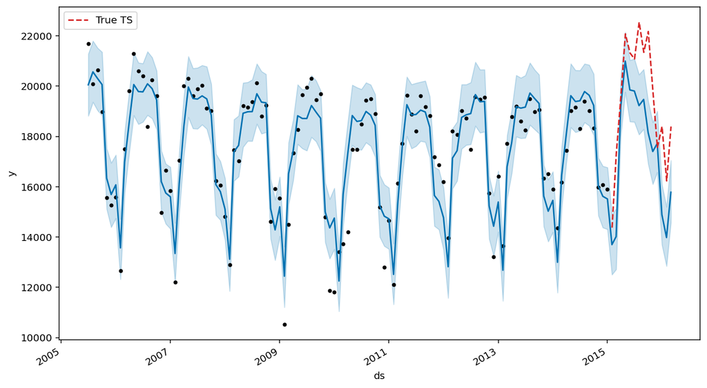

```python
fig1 = m.plot(forecast)

ax = fig1.gca()
ax = test.plot(x='ds', y='y', ls='--', color='C3', ax=ax, label='True TS')
```

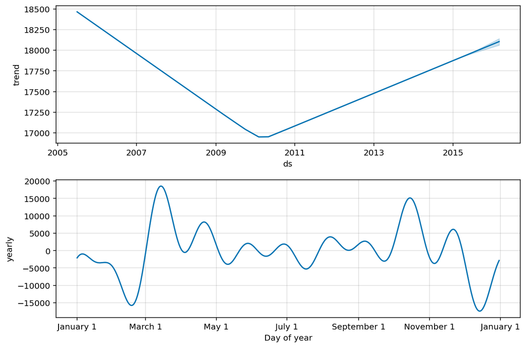

```python
fig2 = m.plot_components(forecast)
```

#### Calculate the RMSE

To the Top

```python
test.head(2)
```

|  | ds | y |
| --- | --- | --- |
| 115 | 2015-02-01 | 14372 |
| 116 | 2015-03-01 | 17304 |

```python
round(np.sqrt(mean_squared_error(test['y'], forecast['yhat'].iloc[-len(test):])), 4)
```

```
2346.5605
```